# Trodecco_Employee_Retention

## **People analytics**

Trodecco is a company operating in LA. Over time, the company has found that after recruiting and training employees, many of their brightest and most experienced employees leave the company for other opportunities. Trodecco wants to understand what causes employees to leave and how to retain their employees. They compiled data for the past 3 years in the file: **Retention.csv** These data include (for each employee):

- **Satisfaction**: (0.0- 1.0) Employee’s self-reported satisfaction level, collected through a recent survey at the company (1.0 is highest)
- **Last_evaluatio**n: (0.0 – 1.0) The employee’s latest annual performance evaluation (1.0 is highest)
- **Project**: (No. of Projects) Average number of projects per month the employee was assigned
- **Monthly_hours**: (hours) Average number of hours the employee worked each month
- **Time**: (years) Number of years the employee has been with the company
- **Left**: (1=yes, 0 = no) Whether the employee quit
- **Promotion**: Whether the employee was promoted in the last 5 years (1=yes, 0 =no)
- **Department**: Department the employee worked in.
- **Salary**: (low, medium, high). Whether the employee’s salary was in the top third, middle third, or top third of salaries for their department.

The second file **Training_Cost.csv** gives the average cost of training a new employee for each department by salary level.

### Part 1: Exploratory data analysis (EDA):

```python
import numpy as np
import pandas as pd
%matplotlib inline
import matplotlib.pyplot as plt
import seaborn as sns

import scipy.stats as ss
from statsmodels.stats.weightstats import ztest

from sklearn.tree import DecisionTreeClassifier
from sklearn.model_selection import train_test_split
```

```python
import warnings
warnings.filterwarnings('ignore')
```

```python
retention = pd.read_csv('Retention.csv', encoding='ISO-8859-1')
retention.head()
```

|  | Satisfaction | Last_evaluation | Project | Monthly_hours | Time | Left | Promotion | Department | Salary |
| --- | --- | --- | --- | --- | --- | --- | --- | --- | --- |
| 0 | 0.71 | 0.36 | 4 | 278 | 4 | 0 | 0 | product_mng | high |
| 1 | 0.44 | 0.36 | 2 | 136 | 3 | 0 | 0 | technical | high |
| 2 | 0.79 | 0.36 | 3 | 114 | 3 | 0 | 0 | technical | high |
| 3 | 0.42 | 0.37 | 2 | 284 | 3 | 0 | 0 | technical | high |
| 4 | 0.96 | 0.37 | 3 | 111 | 2 | 0 | 0 | sales | high |

```python
trainingCost = pd.read_csv('Training_Cost.csv', encoding='ISO-8859-1')
trainingCost
```

|  | Department | high | medium | low |
| --- | --- | --- | --- | --- |
| 0 | accounting | 2000 | 1000 | 1000 |
| 1 | hr | 1300 | 900 | 500 |
| 2 | IT | 4000 | 2000 | 1000 |
| 3 | management | 2000 | 1000 | 300 |
| 4 | marketing | 4000 | 3000 | 600 |
| 5 | product_mng | 3000 | 2000 | 1000 |
| 6 | RandD | 2000 | 2000 | 1000 |
| 7 | sales | 5000 | 2000 | 500 |
| 8 | support | 3000 | 1000 | 300 |
| 9 | technical | 4000 | 2000 | 1000 |

How many employees are in the data set?

```python
retention.shape
```

```
(14999, 9)
```

Are there any missing values?

```python
retention.notna().shape
```

```
(14999, 9)
```

Min, average and max satisfaction score in the data set

```python
retention['Satisfaction'].describe()
```

```
count    14999.000000
mean         0.612834
std          0.248631
min          0.090000
25%          0.440000
50%          0.640000
75%          0.820000
max          1.000000
Name: Satisfaction, dtype: float64
```

Number of departments

```python
retention['Department'].nunique()
```

```
10
```

How many employees are in each department?

```python
retention.groupby('Department')['Satisfaction'].count()
```

```
Department
IT             1227
RandD           787
accounting      767
hr              739
management      630
marketing       858
product_mng     902
sales          4140
support        2229
technical      2720
Name: Satisfaction, dtype: int64
```

Average satisfaction score in each department

```python
retention.groupby('Department')['Satisfaction'].mean()
```

```
Department
IT             0.618142
RandD          0.619822
accounting     0.582151
hr             0.598809
management     0.621349
marketing      0.618601
product_mng    0.619634
sales          0.614447
support        0.618300
technical      0.607897
Name: Satisfaction, dtype: float64
```

Calculate retention rates, i.e., the % of employees that have NOT left, for all departments.

```python
retention_rates = 1 - retention.groupby('Department')['Left'].sum()/retention.groupby('Department')['Left'].count()
retention_rates
```

```
Department
IT             0.777506
RandD          0.846252
accounting     0.734029
hr             0.709066
management     0.855556
marketing      0.763403
product_mng    0.780488
sales          0.755072
support        0.751009
technical      0.743750
Name: Left, dtype: float64
```

```python
retention['Left'].value_counts()
```

```
0    11428
1     3571
Name: Left, dtype: int64
```

```python
retention.groupby('Left').mean()
```

| Left | Satisfaction | Last_evaluation | Project | Monthly_hours | Time | Promotion |
| --- | --- | --- | --- | --- | --- | --- |
| 0 | 0.666810 | 0.714951 | 3.786664 | 199.060203 | 3.380032 | 0.026251 |
| 1 | 0.440098 | 0.720877 | 3.855503 | 207.419210 | 3.876505 | 0.005321 |

```python
retention.groupby('Department').mean()
```

| Department | Satisfaction | Last_evaluation | Project | Monthly_hours | Time | Left | Promotion |
| --- | --- | --- | --- | --- | --- | --- | --- |
| IT | 0.618142 | 0.716634 | 3.816626 | 202.215974 | 3.468623 | 0.222494 | 0.002445 |
| RandD | 0.619822 | 0.711881 | 3.853875 | 200.800508 | 3.367217 | 0.153748 | 0.034307 |
| accounting | 0.582151 | 0.718318 | 3.825293 | 201.162973 | 3.522816 | 0.265971 | 0.018253 |
| hr | 0.598809 | 0.710108 | 3.654939 | 198.684709 | 3.355886 | 0.290934 | 0.020298 |
| management | 0.621349 | 0.723794 | 3.860317 | 201.249206 | 4.303175 | 0.144444 | 0.109524 |
| marketing | 0.618601 | 0.716340 | 3.687646 | 199.385781 | 3.569930 | 0.236597 | 0.050117 |
| product_mng | 0.619634 | 0.714823 | 3.807095 | 199.965632 | 3.475610 | 0.219512 | 0.000000 |
| sales | 0.614447 | 0.710121 | 3.776329 | 200.911353 | 3.534058 | 0.244928 | 0.024155 |
| support | 0.618300 | 0.723194 | 3.803948 | 200.758188 | 3.393001 | 0.248991 | 0.008973 |
| technical | 0.607897 | 0.721379 | 3.877941 | 202.497426 | 3.411397 | 0.256250 | 0.010294 |

```python
retention.groupby('Salary').mean()
```

| Salary | Satisfaction | Last_evaluation | Project | Monthly_hours | Time | Left | Promotion |
| --- | --- | --- | --- | --- | --- | --- | --- |
| high | 0.637470 | 0.704325 | 3.767179 | 199.867421 | 3.692805 | 0.066289 | 0.058205 |
| low | 0.600753 | 0.717017 | 3.799891 | 200.996583 | 3.438218 | 0.296884 | 0.009021 |
| medium | 0.621817 | 0.717927 | 3.813528 | 201.338349 | 3.529010 | 0.204313 | 0.028079 |

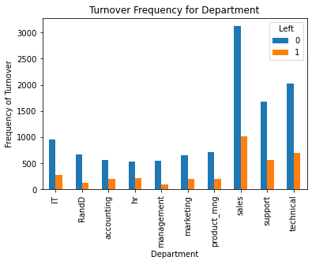

```python
%matplotlib inline
import matplotlib.pyplot as plt
pd.crosstab(retention.Department,retention.Left).plot(kind='bar')
plt.title('Turnover Frequency for Department')
plt.xlabel('Department')
plt.ylabel('Frequency of Turnover')
plt.savefig('department_bar_chart')
```

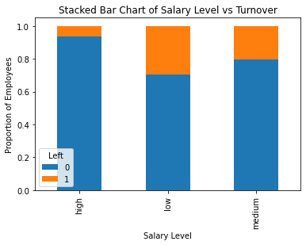

```python
table=pd.crosstab(retention.Salary, retention.Left)
table.div(table.sum(1).astype(float), axis=0).plot(kind='bar', stacked=True)
plt.title('Stacked Bar Chart of Salary Level vs Turnover')
plt.xlabel('Salary Level')
plt.ylabel('Proportion of Employees')
plt.savefig('salary_bar_chart')
```

```python
pd.crosstab(retention.Department, retention.Left)
```

| Left Department | 0 | 1 |
| --- | --- | --- |
| IT | 954 | 273 |
| RandD | 666 | 121 |
| accounting | 563 | 204 |
| hr | 524 | 215 |
| management | 539 | 91 |
| marketing | 655 | 203 |
| product_mng | 704 | 198 |
| sales | 3126 | 1014 |
| support | 1674 | 555 |
| technical | 2023 | 697 |

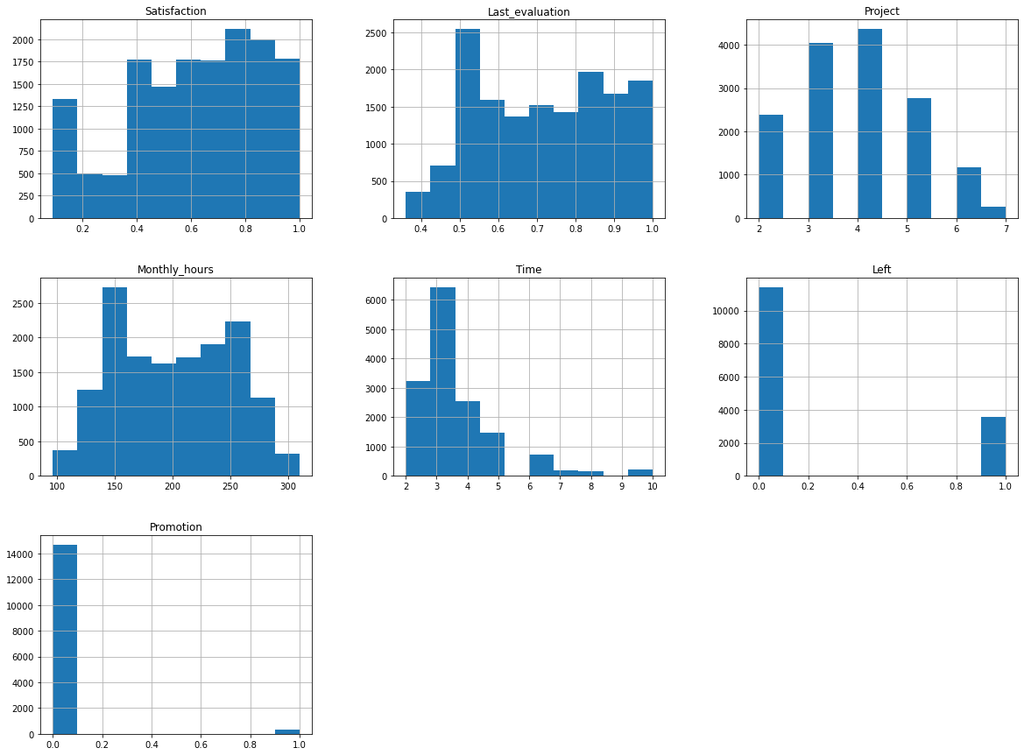

```python
num_bins = 10

retention.hist(bins=num_bins, figsize=(20,15))
plt.show()
```

Which department has the lowest retention rate?

```python
retention_rates.loc['hr']
```

```
0.7090663058186739
```

Fill in data from Training Cost dataset.

```python
retention['trainingCost'] = trainingCost.set_index('Department').lookup(retention['Department'],retention['Salary'])
retention.head()
```

|  | Satisfaction | Last_evaluation | Project | Monthly_hours | Time | Left | Promotion | Department | Salary | trainingCost |
| --- | --- | --- | --- | --- | --- | --- | --- | --- | --- | --- |
| 0 | 0.71 | 0.36 | 4 | 278 | 4 | 0 | 0 | product_mng | high | 3000 |
| 1 | 0.44 | 0.36 | 2 | 136 | 3 | 0 | 0 | technical | high | 4000 |
| 2 | 0.79 | 0.36 | 3 | 114 | 3 | 0 | 0 | technical | high | 4000 |
| 3 | 0.42 | 0.37 | 2 | 284 | 3 | 0 | 0 | technical | high | 4000 |
| 4 | 0.96 | 0.37 | 3 | 111 | 2 | 0 | 0 | sales | high | 5000 |

What is the total training cost spent for all the employees?

```python
retention['trainingCost'].sum()
```

```
20567600
```

What is the percentage spent on those who have left the company?

```python
retention.groupby('Left')['trainingCost'].sum()[1]/retention['trainingCost'].sum()
```

```
0.19397498978976643
```

Which department spends the largest fraction of its training costs on employees that ultimately leave the company?

```python
retention[retention['Left']==1].groupby('Department')['trainingCost'].sum()/retention.groupby('Department')['trainingCost'].sum()
```

```
Department
IT             0.189955
RandD          0.154545
accounting     0.248514
hr             0.289747
management     0.069547
marketing      0.186834
product_mng    0.209008
sales          0.172518
support        0.174801
technical      0.238479
Name: trainingCost, dtype: float64
```

### Part 2: AB testing:

There is a belief that the best employees , i.e., the employees with the highest evaluation scores, are the ones that are leaving the company. Let's take a closer look with A/B Testing.

```python
R = retention.loc[retention['Left']==0,'Last_evaluation']
L = retention.loc[retention['Left']==1,'Last_evaluation']
```

```python
ss.stats.ttest_ind(a=R, b=L,equal_var=False,alternative='greater')
```

```
Ttest_indResult(statistic=-1.6508075726997398, pvalue=0.9505808315672778)
```

Data does not provide significant enough evidence that better than average employees are leaving.

The problem might be that the best employees might be leaving because they feel underpaid. If that were true, you might expect a (statistically significant) difference in evaluation scores between the employees who left and the employees who stayed, particularly at the “high” salary level.

```python
RH = retention[retention['Salary']=='high'].loc[retention['Left']==0,'Last_evaluation']
LH = retention[retention['Salary']=='high'].loc[retention['Left']==1,'Last_evaluation']
```

```python
ss.stats.ttest_ind(a=RH, b=LH,equal_var=False,alternative='greater')
```

```
Ttest_indResult(statistic=3.082181370261907, pvalue=0.0013663080445550345)
```

Consider the other salary levels.

```python
RM = retention[retention['Salary']=='medium'].loc[retention['Left']==0,'Last_evaluation']
LM = retention[retention['Salary']=='medium'].loc[retention['Left']==1,'Last_evaluation']
```

```python
ss.stats.ttest_ind(a=RM, b=LM,equal_var=False,alternative='greater')
```

```
Ttest_indResult(statistic=-3.1063203806486315, pvalue=0.9990382952951038)
```

```python
RL = retention[retention['Salary']=='low'].loc[retention['Left']==0,'Last_evaluation']
LL = retention[retention['Salary']=='low'].loc[retention['Left']==1,'Last_evaluation']
```

```python
ss.stats.ttest_ind(a=RL, b=LL,equal_var=False,alternative='greater')
```

```
Ttest_indResult(statistic=0.007113352772731251, pvalue=0.4971624104987519)
```

Salary clusters may be based on the variability of the risk of losing a specific employee.

In this case "Salary" was a confounding variable in our initial consideration of the evaluation metric, as it was evenly dispersed between that and the dependent variable "Left" but ended up having some significant correlation with each.

### Part 3: Model building:

There are two categorical variables in the dataset and they need to be converted to dummy variables before they can be used for modelling.

```python
retention.head()
```

|  | Satisfaction | Last_evaluation | Project | Monthly_hours | Time | Left | Promotion | Department | Salary | trainingCost |
| --- | --- | --- | --- | --- | --- | --- | --- | --- | --- | --- |
| 0 | 0.71 | 0.36 | 4 | 278 | 4 | 0 | 0 | product_mng | high | 3000 |
| 1 | 0.44 | 0.36 | 2 | 136 | 3 | 0 | 0 | technical | high | 4000 |
| 2 | 0.79 | 0.36 | 3 | 114 | 3 | 0 | 0 | technical | high | 4000 |
| 3 | 0.42 | 0.37 | 2 | 284 | 3 | 0 | 0 | technical | high | 4000 |
| 4 | 0.96 | 0.37 | 3 | 111 | 2 | 0 | 0 | sales | high | 5000 |

```python
cat_vars=['Department','Salary']
for var in cat_vars:
    cat_list='var'+'_'+var
    cat_list = pd.get_dummies(retention[var], prefix=var)
    r1=retention.join(cat_list)
    retention=r1
```

The actual categorical variable needs to be removed once the dummy variables have been created.

```python
retention.drop(['Department', 'Salary'], axis=1, inplace=True)
```

```python
retention.columns.values
```

```
array(['Satisfaction', 'Last_evaluation', 'Project', 'Monthly_hours',
       'Time', 'Left', 'Promotion', 'trainingCost', 'Department_IT',
       'Department_RandD', 'Department_accounting', 'Department_hr',
       'Department_management', 'Department_marketing',
       'Department_product_mng', 'Department_sales', 'Department_support',
       'Department_technical', 'Salary_high', 'Salary_low',
       'Salary_medium'], dtype=object)
```

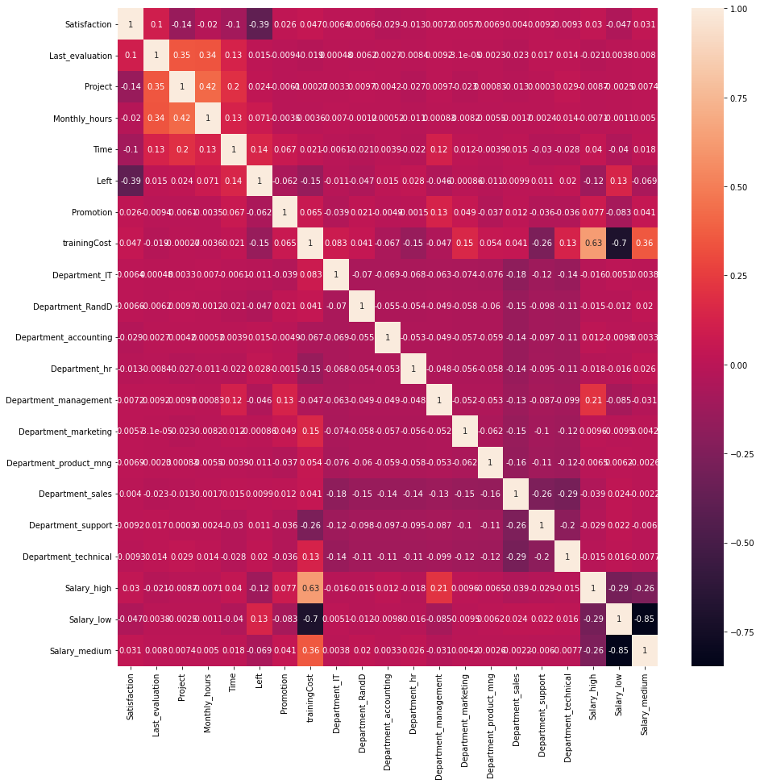

```python
plt.figure(figsize=(15, 15))
sns.heatmap(retention.corr(), annot=True)
```

```python
retention_vars=retention.columns.values.tolist()
y=['Left']
X=[i for i in retention_vars if i not in y]
```

```python
X
```

```
['Satisfaction',
 'Last_evaluation',
 'Project',
 'Monthly_hours',
 'Time',
 'Promotion',
 'trainingCost',
 'Department_IT',
 'Department_RandD',
 'Department_accounting',
 'Department_hr',
 'Department_management',
 'Department_marketing',
 'Department_product_mng',
 'Department_sales',
 'Department_support',
 'Department_technical',
 'Salary_high',
 'Salary_low',
 'Salary_medium']
```

```python
from sklearn.feature_selection import RFE
from sklearn.linear_model import LogisticRegression

model = LogisticRegression()

rfe = RFE(model)
rfe = rfe.fit(retention[X], retention[y])
print(rfe.support_)
print(rfe.ranking_)
```

```
[ True  True False False  True  True False False  True False  True  True
 False False False False False  True  True  True]
[ 1  1  2  9  1  1 11  3  1  7  1  1  8  4 10  6  5  1  1  1]
```

```python
cols=['Satisfaction', 'Last_evaluation', 'Time',
      'Department_IT', 'Department_accounting', 'Department_hr', 'Department_management', 'Salary_high', 'Salary_low', 'Salary_low']
X=retention[cols]
y=retention['Left']
```

### Logistic regression model

```python
from sklearn.model_selection import train_test_split
X_train, X_test, y_train, y_test = train_test_split(X, y, test_size=0.3, random_state=0)
```

```python
from sklearn.linear_model import LogisticRegression
from sklearn import metrics
logreg = LogisticRegression()
logreg.fit(X_train, y_train)
```

```
LogisticRegression()
```

```python
from sklearn.metrics import accuracy_score
print('Logistic regression accuracy: {:.3f}'.format(accuracy_score(y_test, logreg.predict(X_test))))
```

```
Logistic regression accuracy: 0.762
```

### Random Forest

```python
from sklearn.ensemble import RandomForestClassifier
rf = RandomForestClassifier()
rf.fit(X_train, y_train)
```

```
RandomForestClassifier()
```

```python
print('Random Forest Accuracy: {:.3f}'.format(accuracy_score(y_test, rf.predict(X_test))))
```

```
Random Forest Accuracy: 0.981
```

### Support Vector Machine

```python
from sklearn.svm import SVC
svc = SVC()
svc.fit(X_train, y_train)
```

```
SVC()
```

```python
print('Support vector machine accuracy: {:.3f}'.format(accuracy_score(y_test, svc.predict(X_test))))
```

```
Support vector machine accuracy: 0.898
```

```python
from sklearn import model_selection
from sklearn.model_selection import cross_val_score
kfold = model_selection.KFold(n_splits=10)
modelCV = RandomForestClassifier()
scoring = 'accuracy'
results = model_selection.cross_val_score(modelCV, X_train, y_train, cv=kfold, scoring=scoring)
print("10-fold cross validation average accuracy: %.3f" % (results.mean()))
```

```
10-fold cross validation average accuracy: 0.980
```

### Precision and recall

```python
from sklearn.metrics import classification_report
print(classification_report(y_test, rf.predict(X_test)))
```

```
              precision    recall  f1-score   support

           0       0.99      0.99      0.99      3421
           1       0.96      0.96      0.96      1079

    accuracy                           0.98      4500
   macro avg       0.97      0.97      0.97      4500
weighted avg       0.98      0.98      0.98      4500
```

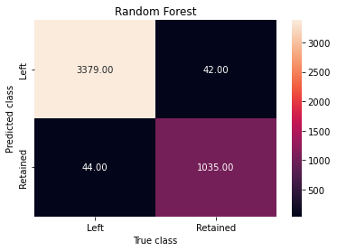

```python
y_pred = rf.predict(X_test)
from sklearn.metrics import confusion_matrix
import seaborn as sns
forest_cm = metrics.confusion_matrix(y_test, y_pred)
sns.heatmap(forest_cm, annot=True, fmt='.2f',xticklabels = ["Left", "Retained"] , yticklabels = ["Left", "Retained"] )
plt.xlabel('True class')
plt.ylabel('Predicted class')
plt.title('Random Forest')
plt.savefig('random_forest')
```

```python
print(classification_report(y_test, logreg.predict(X_test)))
```

```
              precision    recall  f1-score   support

           0       0.80      0.92      0.85      3421
           1       0.51      0.26      0.34      1079

    accuracy                           0.76      4500
   macro avg       0.65      0.59      0.60      4500
weighted avg       0.73      0.76      0.73      4500
```

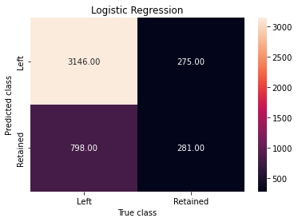

```python
logreg_y_pred = logreg.predict(X_test)
logreg_cm = metrics.confusion_matrix(y_test,logreg_y_pred)
sns.heatmap(logreg_cm, annot=True, fmt='.2f',xticklabels = ["Left", "Retained"] , yticklabels = ["Left", "Retained"] )
plt.xlabel('True class')
plt.ylabel('Predicted class')
plt.title('Logistic Regression')
plt.savefig('logistic_regression')
```

```python
print(classification_report(y_test, svc.predict(X_test)))
```

```
              precision    recall  f1-score   support

           0       0.95      0.91      0.93      3421
           1       0.76      0.85      0.80      1079

    accuracy                           0.90      4500
   macro avg       0.85      0.88      0.87      4500
weighted avg       0.90      0.90      0.90      4500
```

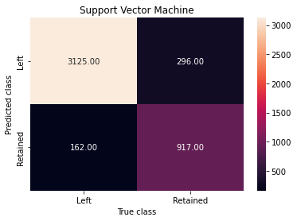

```python
svc_y_pred = svc.predict(X_test)
svc_cm = metrics.confusion_matrix(y_test, svc_y_pred)
sns.heatmap(svc_cm, annot=True, fmt='.2f',xticklabels = ["Left", "Retained"] , yticklabels = ["Left", "Retained"] )
plt.xlabel('True class')
plt.ylabel('Predicted class')
plt.title('Support Vector Machine')
plt.savefig('support_vector_machine')
```

When an employee left, how often does my classifier predict that correctly? This measurement is called "recall" and a quick look at these diagrams can demonstrate that random forest is clearly best for this criteria. Out of all the turnover cases, random forest correctly retrieved 1035 out of 1079. This translates to a turnover "recall" of about 96%, far better than logistic regression (26%) or support vector machines (85%).

When a classifier predicts an employee will leave, how often does that employee actually leave? This measurement is called "precision". Random forest again out preforms the other two at about 96% precision (1035 out of 1077) with logistic regression at about 51% (281 out of 556), and support vector machine at about 76% (917 out of 1213).

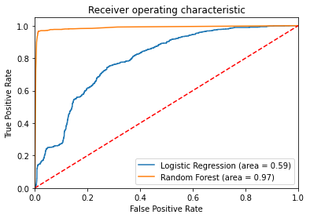

```python
from sklearn.metrics import roc_auc_score
from sklearn.metrics import roc_curve

logit_roc_auc = roc_auc_score(y_test, logreg.predict(X_test))
fpr, tpr, thresholds = roc_curve(y_test, logreg.predict_proba(X_test)[:,1])

rf_roc_auc = roc_auc_score(y_test, rf.predict(X_test))
rf_fpr, rf_tpr, rf_thresholds = roc_curve(y_test, rf.predict_proba(X_test)[:,1])

plt.figure()
plt.plot(fpr, tpr, label='Logistic Regression (area = %0.2f)' % logit_roc_auc)
plt.plot(rf_fpr, rf_tpr, label='Random Forest (area = %0.2f)' % rf_roc_auc)
plt.plot([0, 1], [0, 1],'r--')
plt.xlim([0.0, 1.0])
plt.ylim([0.0, 1.05])
plt.xlabel('False Positive Rate')
plt.ylabel('True Positive Rate')
plt.title('Receiver operating characteristic')
plt.legend(loc="lower right")
plt.savefig('ROC')
plt.show()
```

```python
feature_labels = np.array(['Satisfaction', 'Last_evaluation', 'Time',
      'Department_IT', 'Department_accounting', 'Department_hr', 'Department_management', 'Salary_high', 'Salary_low', 'Salary_low'])
importance = rf.feature_importances_
feature_indexes_by_importance = importance.argsort()
for index in feature_indexes_by_importance:
    print('{}-{:.2f}%'.format(feature_labels[index], (importance[index] *100.0)))
```

```
Department_management-0.25%
Department_IT-0.25%
Department_hr-0.26%
Department_accounting-0.34%
Salary_low-0.52%
Salary_low-0.59%
Salary_high-0.83%
Last_evaluation-19.60%
Time-25.82%
Satisfaction-51.55%
```